# Posterior Predictive Distribution + A PREDICTOR

STAT 341, Spring 2023

2023-02-10

## Model

Recall Prof DR’s model for Fijian income:

$$\text{annual income}_i \sim
\text{Normal}(\mu, \sigma)$$
$$\mu
\sim \text{Normal}(\text{mean}_1 = 50, \text{sd}_1 = 20)$$
$$\sigma \sim \text{Normal}(\text{mean}_2 = 15,
\text{sd}_2 = 20)$$
We can fit the model with `quap()`.

```r
model_descrip <- alist(
  # note variable name has to match actual data variable name
  household_annual_income ~ dnorm(mu, sigma),
  mu ~ dnorm(mean = 50, sd = 20),
  sigma ~ dnorm(mean = 15, sd = 20)
)

quap_income_model <- quap(flist = model_descrip,
                          data = fiji)
quap_income_post_sample <- extract.samples(quap_income_model, n = 1000)
```

If we look at the posterior sample, we can get an idea of our estimates of the *mean* and *standard deviation* of incomes:

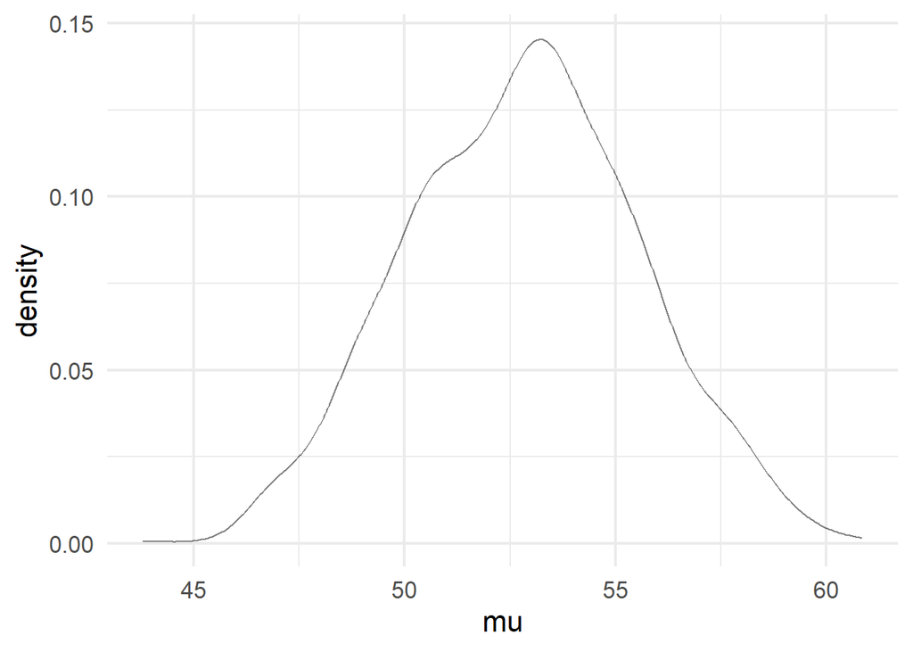

```r
gf_dens(~mu, data = quap_income_post_sample)
```

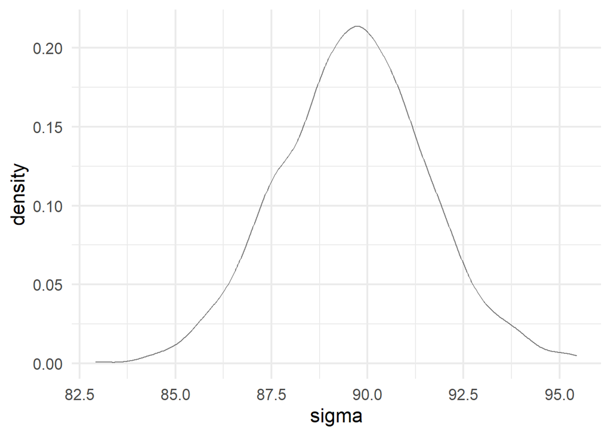

```r
gf_dens(~sigma, data = quap_income_post_sample)
```

But what about the distribution of *incomes* we might expect? Specifically, if we simulate many datasets (the same size as our real `fiji` one), how do those distributions compare to the observed distribution of the real data? Do they seem to match up well?

```r
income_ppred <- quap_income_post_sample |>
  # add row numbers to "label" each sampled combo of mu & sigma
  mutate(row_num = c(1:n())) |>
  # work one row (one mu, sigma combination) at a time
  rowwise() |>
  # simulate a dataset for each row (= each mu, sigma combo)
  mutate(ppred = list(rnorm(nrow(fiji),
                            mean = mu,
                            sd = sigma))) |>
  # keep only the row-ids and the simulated data
  select(row_num, ppred)

# note the structure: each row's ppred is a LIST of incomes nrow(fiji) long
glimpse(income_ppred)
```

```
## Rows: 1,000
## Columns: 2
## Rowwise:
## $ row_num <int> 1, 2, 3, 4, 5, 6, 7, 8, 9, 10, 11, 12, 13, 14, 15, 16, 17, 18,…
## $ ppred   <list> <-43.85775062, -35.86891232, 104.35370702, 143.53493597, 65.9…
```

```r
# "unnest" results so each observed income is in its own row instead of a list. Now there are nrow(fiji) rows for each mu, sigma combo
income_ppred <- income_ppred |>
  unnest(cols = ppred)

# peek at the final result
glimpse(income_ppred)
```

```
## Rows: 1,006,000
## Columns: 2
## $ row_num <int> 1, 1, 1, 1, 1, 1, 1, 1, 1, 1, 1, 1, 1, 1, 1, 1, 1, 1, 1, 1, 1,…
## $ ppred   <dbl> -43.857751, -35.868912, 104.353707, 143.534936, 65.980247, 168…
```

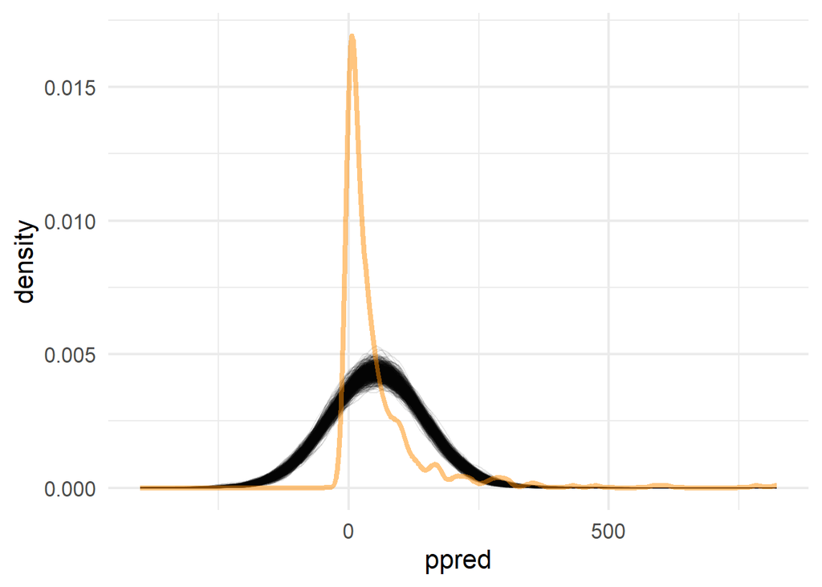

```r
# graph simulated datasets - one line for each mu,sigma combo
# this will take a while unless you reduce n above in extract.samples()!
gf_dens(~ppred, group = ~row_num,
        data = income_ppred,
        alpha = 0.1) |>
  # overlay actual data
  gf_dens(~household_annual_income,
          data = fiji,
          inherit = FALSE,
          color = 'darkorange',
          linewidth = 1.5)
```

#### Question: Is this good, or bad? What is going on?

> Our posterior prediction distribution is lower and more spread out than the actual data.

> I think this is bad because the posterior predictive distribution is not capturing the true data, meaning we are missing some important variables in the model.

*Stay tuned for Homework 4 for some progress…*

#### Task: Generate a posterior predictive distribution for your `water_expenses_pp` model fitted with `quap()`.

```r
model_descrip <- alist(
  # note variable name has to match actual data variable name
  water_expenses_pp ~ dnorm(mu, sigma),
  mu ~ dnorm(mean = 10, sd = 3),
  sigma ~ dunif(min = 0, max = 3)
)

quap_water_expenses_model <- quap(flist = model_descrip,
                          data = fiji)
quap_water_expenses_post_sample <- extract.samples(quap_water_expenses_model, n = 1000)
```

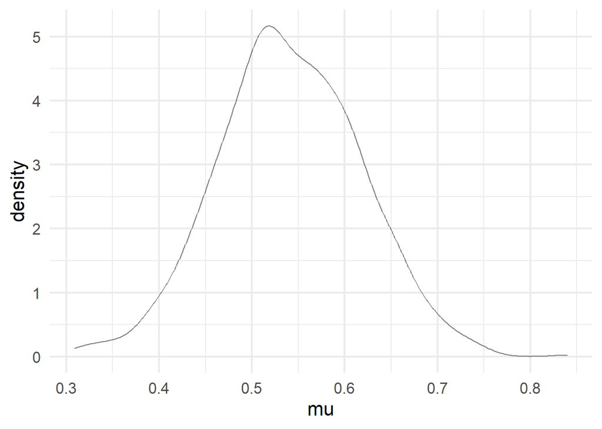

```r
gf_dens(~mu, data = quap_water_expenses_post_sample)
```

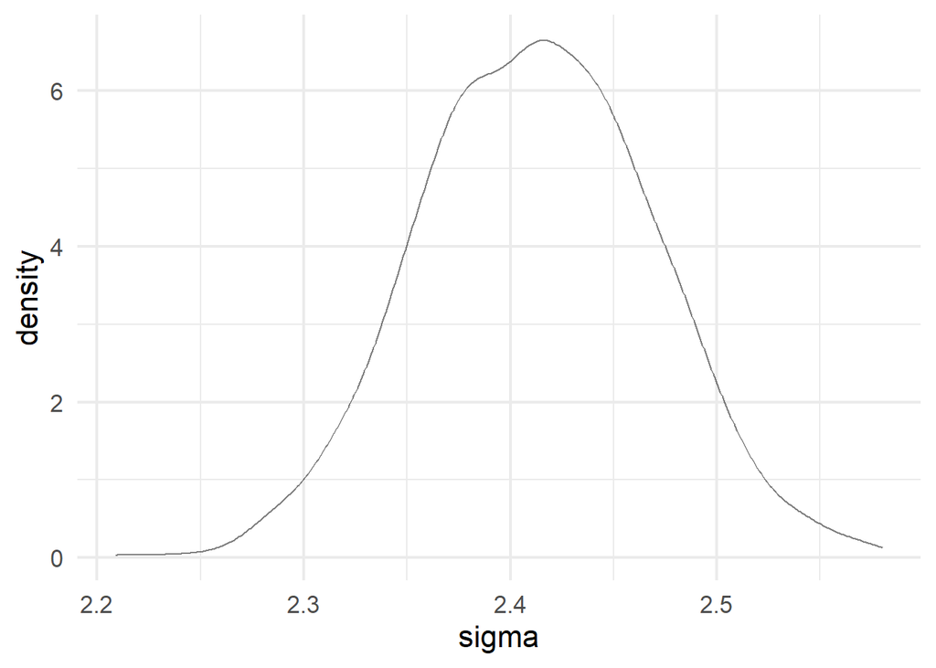

```r
gf_dens(~sigma, data = quap_water_expenses_post_sample)
```

```r
water_expenses_ppred <- quap_water_expenses_post_sample |>
  # add row numbers to "label" each sampled combo of mu & sigma
  mutate(row_num = c(1:n())) |>
  # work one row (one mu, sigma combination) at a time
  rowwise() |>
  # simulate a dataset for each row (= each mu, sigma combo)
  mutate(ppred = list(rnorm(nrow(fiji),
                            mean = mu,
                            sd = sigma))) |>
  # keep only the row-ids and the simulated data
  select(row_num, ppred)

# note the structure: each row's ppred is a LIST of incomes nrow(fiji) long
glimpse(water_expenses_ppred)
```

```
## Rows: 1,000
## Columns: 2
## Rowwise:
## $ row_num <int> 1, 2, 3, 4, 5, 6, 7, 8, 9, 10, 11, 12, 13, 14, 15, 16, 17, 18,…
## $ ppred   <list> <1.0874758740, -2.8271802224, -3.1636212447, 1.8749973020, -2…
```

```r
# "unnest" results so each observed income is in its own row instead of a list. Now there are nrow(fiji) rows for each mu, sigma combo
water_expenses_ppred <- water_expenses_ppred |>
  unnest(cols = ppred)

# peek at the final result
glimpse(water_expenses_ppred)
```

```
## Rows: 1,006,000
## Columns: 2
## $ row_num <int> 1, 1, 1, 1, 1, 1, 1, 1, 1, 1, 1, 1, 1, 1, 1, 1, 1, 1, 1, 1, 1,…
## $ ppred   <dbl> 1.0874759, -2.8271802, -3.1636212, 1.8749973, -2.5585467, -4.5…
```

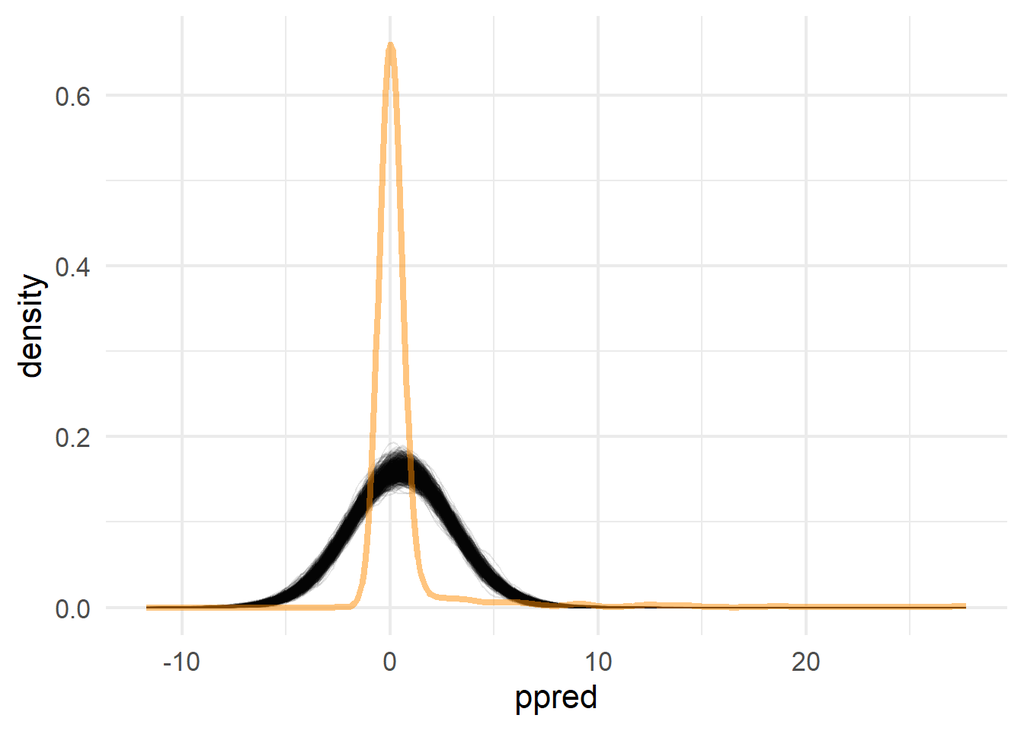

```r
# graph simulated datasets - one line for each mu,sigma combo
# this will take a while unless you reduce n above in extract.samples()!
gf_dens(~ppred, group = ~row_num,
        data = water_expenses_ppred,
        alpha = 0.1) |>
  # overlay actual data
  gf_dens(~water_expenses_pp,
          data = fiji,
          inherit = FALSE,
          color = 'darkorange',
          linewidth = 1.5)
```

## Predictor!

We want to reach a point where we can model *multiple* variables at a time, and quantify their associations (if any).

Once we have more than 2 we will use causal diagrams to guide our model design and decide which variables to include in a model.

We will start, for now, with just two variables though. Consider the variable you’ve been working with (`houshold_annual_income` for me, `water_expenses_pp` for you) as the response variable.

#### Task: identify one quantitative variable that could be a predictor of your response.

> I will choose `n_total` as a possible predictor since I think having multiple potential water consumer in the house will lead to higher water expense for the group.

*For `household_annual_income`, I will choose `n_adults` as a possible predictor since I think having multiple potential earners in the house will lead to higher incomes for the group.*

My model will now be:

$$\text{household annual income}_i \sim
\text{Normal}(\mu_i, \sigma)$$
$$\mu_i
\sim \beta_0 + \beta_1 * \text{n adults}$$
$$\beta_0 \sim \text{Normal}(30,20)$$
$$\beta_1 \sim \text{Normal}(20, 10)$$
$$\sigma \sim \text{Normal}(15,20)$$

Now, the *first two* lines of the description state the structure of the model and tell how the likelihood will be determined. The last three are all priors.

#### Question: Can you state in words what each line of the description means? For priors, include statements in terms of income dollars, people, etc.

> 1. Household annual income is normally distributed with mean $\mu_i$ and $\sigma$.
> 2. The $\mu_i$ is base income $\beta_0$ + additional income per adult $\beta_1$ * b adults.
> 3. Prior base income per household $\beta_0$ is normally distributed with a mean of 30000 dollars and a standard deviation of 20000 dollars.
> 4. Prior additional income per adult $\beta_1$ is normally distributed with a mean of 20000 dollars and a standard deviation of 10000 dollars.
> 5. The standard deviation of household annual income is normally distributed with a mean of 15000 dollars and a standard deviation of 20000 dollars

#### Question: What’s with the $i$ subscripts?

> Different $\mu_i$ represents different individual household.

#### Question: $\text{Normal}(0,\sigma)$ is often considered an “uninformative” prior for $\beta_1$. Can you explain why, in words? Why didn’t I use it here?

> An uninformative prior is a prior that has minimal influence on the inference.

> $\text{Normal}(0, \sigma)$ is often considered an “uninformative” prior because it assumes no prior knowledge about the parameter, allowing the data to influence the posterior more.

> You didn’t use it here because each additional adult increases income, so you want to have a more informative prior.

#### Task: Generate a prior predictive distribution for this model. (Start with the code above for the *posterior* predictive distribution – but you’ll need to generate your own draws from the priors instead of starting with a posterior sample.) Describe (or implement) any changes you think are needed.

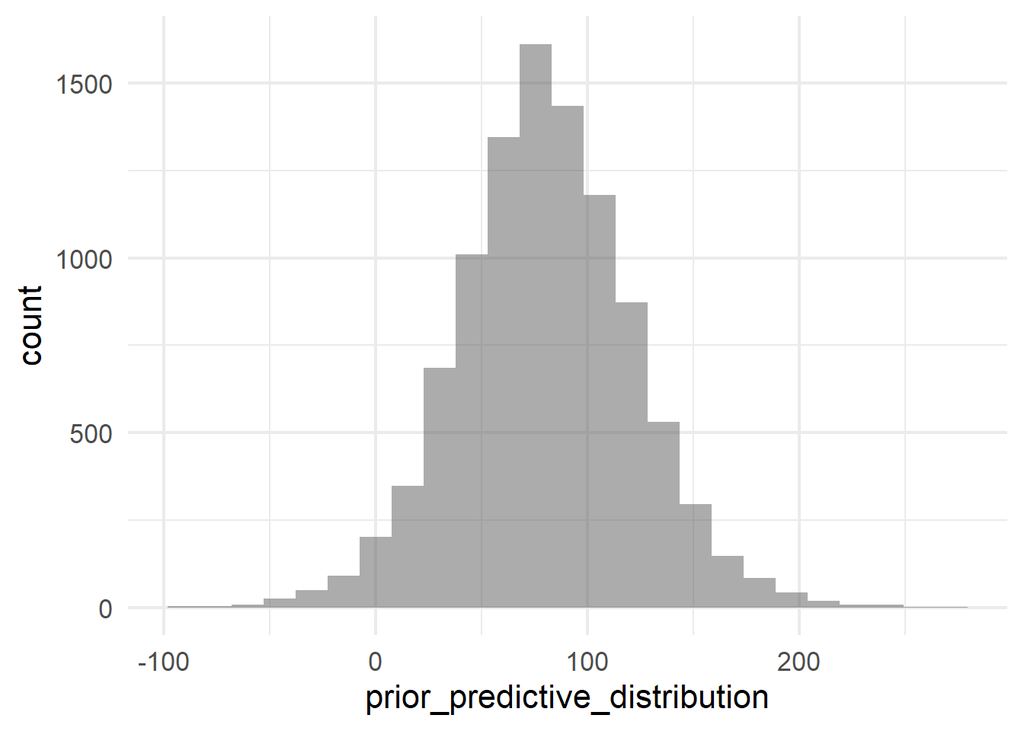

```r
n_samples <- 10000

beta_0_prior <- rnorm(n_samples, mean = 30, sd = 20)
beta_1_prior <- rnorm(n_samples, mean = 20, sd = 10)
sigma_prior <- abs(rnorm(n_samples, mean = 15, sd = 20))

mu_prior <- beta_0_prior + beta_1_prior * mean(fiji$n_adults, na.rm = TRUE)
prior_predictive_distribution <- rnorm(n_samples, mean = mu_prior, sd = sigma_prior)

gf_histogram(~prior_predictive_distribution)
```

```r
# Number of prior predictive samples
n_samples <- 10000

prior_samples <- tibble(
  beta_0 = rnorm(n_samples, mean = 30, sd = 20),
  beta_1 = rnorm(n_samples, mean = 20, sd = 10),
  sigma = abs(rnorm(n_samples, mean = 15, sd = 20))
)

prior_ppred <- prior_samples |>
  # add row numbers to "label" each sampled combo of beta_0, beta_1, and sigma
  mutate(row_num = c(1:n_samples)) |>
  # work one row (one beta_0, beta_1, sigma combination) at a time
  rowwise() |>
  # simulate a dataset for each row (= each beta_0, beta_1, sigma combo)
  mutate(ppred = list(rnorm(nrow(fiji),
                            mean = beta_0 + beta_1 * fiji$n_adults,
                            sd = sigma))) |>
  # keep only the row-ids and the simulated data
  select(row_num, ppred)

# "unnest" results so each observed income is in its own row instead of a list. Now there are nrow(fiji) rows for each beta_0, beta_1, sigma combo
prior_ppred <- prior_ppred |>
  unnest(cols = ppred)

# Peek at the final result
glimpse(prior_ppred)
```

```
## Rows: 10,060,000
## Columns: 2
## $ row_num <int> 1, 1, 1, 1, 1, 1, 1, 1, 1, 1, 1, 1, 1, 1, 1, 1, 1, 1, 1, 1, 1,…
## $ ppred   <dbl> 92.77632, 104.72145, 106.21979, 43.30552, 114.55865, 115.86852…
```

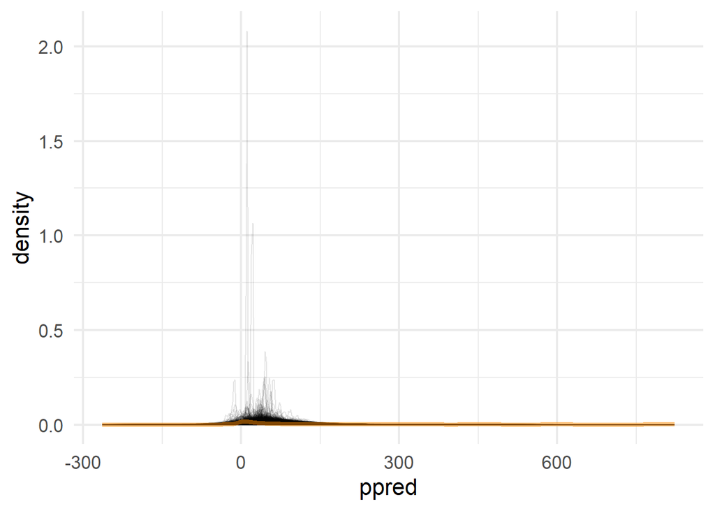

```r
gf_dens(~ppred, group = ~row_num,
        data = prior_ppred,
        alpha = 0.1) |>
  # overlay actual data
  gf_dens(~household_annual_income,
          data = fiji,
          inherit = FALSE,
          color = 'darkorange',
          linewidth = 1.5)
```

#### Task: Fit this model using `quap()`. (Code is given below if you need it - for more challenge try to do it on your own.)

```r
hh_size_income_mod <- quap(
  flist = alist(
    household_annual_income ~ dnorm(mu, sigma),
    mu ~ b0 + b1 * n_adults,
    b0 ~ dnorm(30,20),
    b1 ~ dnorm(20,10),
    sigma ~ dnorm(15,20)
  ),
  data = fiji)
precis(hh_size_income_mod)
```

```
##           mean       sd      5.5%    94.5%
## b0    11.25012 5.094050  3.108841 19.39139
## b1    16.60701 1.746063 13.816462 19.39755
## sigma 86.12474 1.890074 83.104040 89.14545
```

#### Task/Question: generate and plot a posterior sample and a posterior predictive distribution. What do you think?

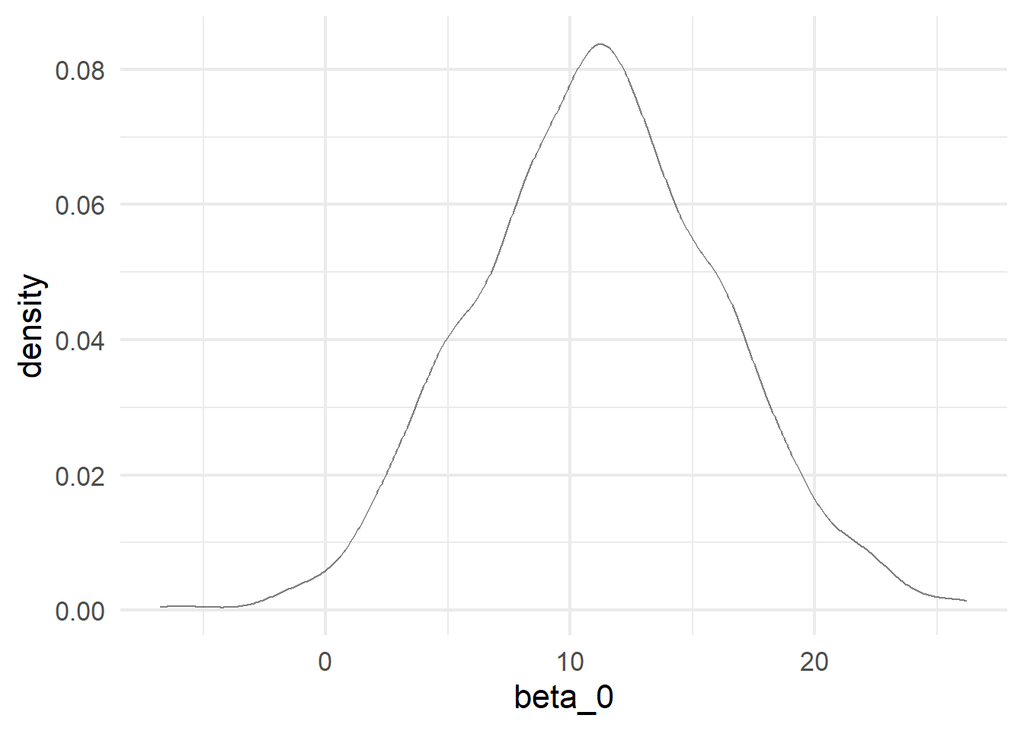

```r
model_descrip <- alist(
  household_annual_income ~ dnorm(mu, sigma),
  mu <- beta_0 + beta_1 * n_adults,
  beta_0 ~ dnorm(mean = 30, sd = 20),
  beta_1 ~ dnorm(mean = 20, sd = 10),
  sigma ~ dnorm(mean = 15, sd = 20)
)

quap_income_model <- quap(flist = model_descrip,
                          data = fiji)
quap_income_post_sample <- extract.samples(quap_income_model, n = 1000)

gf_dens(~beta_0, data = quap_income_post_sample)
```

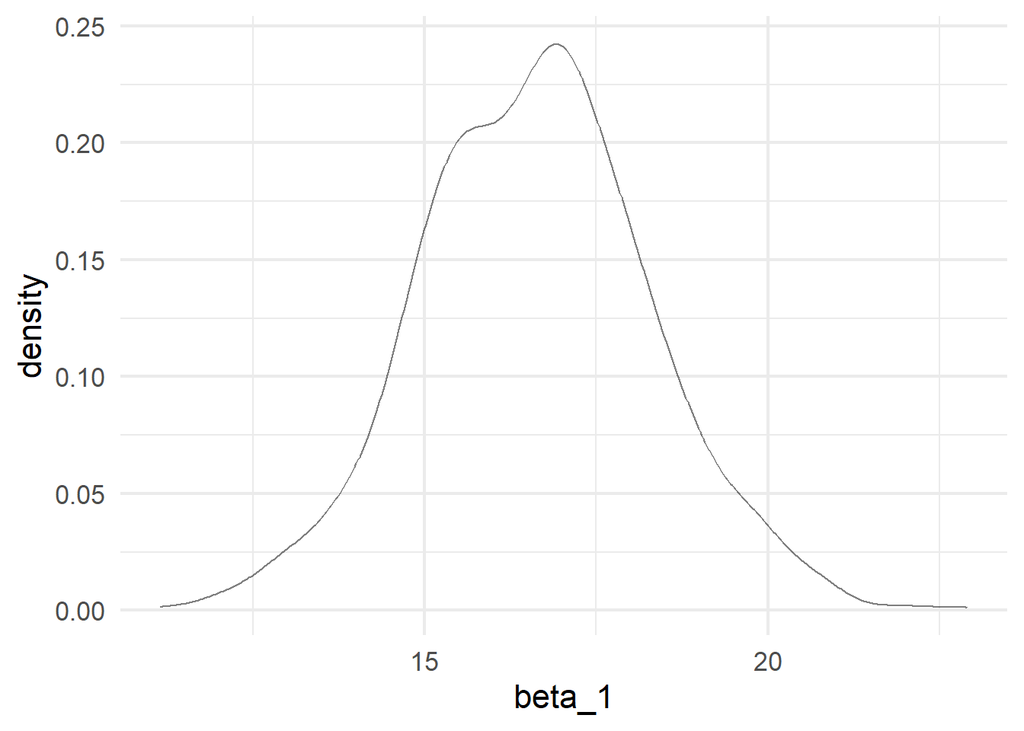

```r
gf_dens(~beta_1, data = quap_income_post_sample)
```

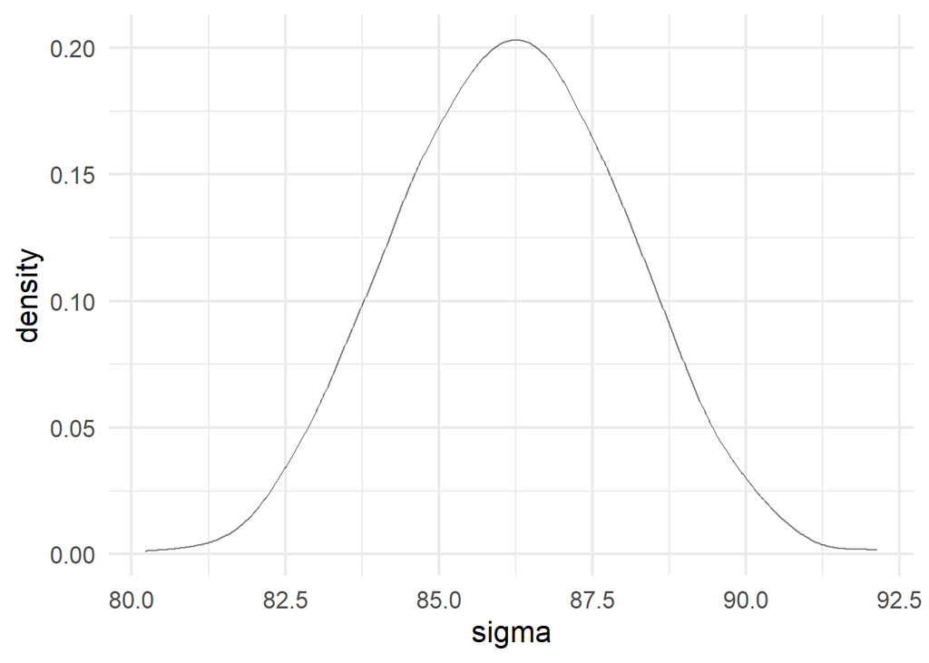

```r
gf_dens(~sigma, data = quap_income_post_sample)
```

```r
posterior_ppred <- quap_income_post_sample |>
  # add row numbers to "label" each sampled of beta_0, beta_1, and sigma
  mutate(row_num = c(1:n())) |>
  # work one row (one beta_0, beta_1, sigma combination) at a time
  rowwise() |>
  # simulate a dataset for each row (= each beta_0, beta_1, sigma combo)
  mutate(ppred = list(rnorm(nrow(fiji),
                            mean = beta_0 + beta_1 * fiji$n_adults,
                            sd = sigma))) |>
  # keep only the row-ids and the simulated data
  select(row_num, ppred)

# note the structure: each row's ppred is a LIST of incomes nrow(fiji) long
glimpse(posterior_ppred)
```

```
## Rows: 1,000
## Columns: 2
## Rowwise:
## $ row_num <int> 1, 2, 3, 4, 5, 6, 7, 8, 9, 10, 11, 12, 13, 14, 15, 16, 17, 18,…
## $ ppred   <list> <42.2721578, -60.5410674, 125.9886398, 123.8198795, 121.30333…
```

```r
# "unnest" results so each observed income is in its own row instead of a list. Now there are nrow(fiji) rows for each beta_0, beta_1, sigma combo
posterior_ppred <- posterior_ppred |>
  unnest(cols = ppred)

# Peek at the final result
glimpse(posterior_ppred)
```

```
## Rows: 1,006,000
## Columns: 2
## $ row_num <int> 1, 1, 1, 1, 1, 1, 1, 1, 1, 1, 1, 1, 1, 1, 1, 1, 1, 1, 1, 1, 1,…
## $ ppred   <dbl> 42.27216, -60.54107, 125.98864, 123.81988, 121.30333, 149.0078…
```

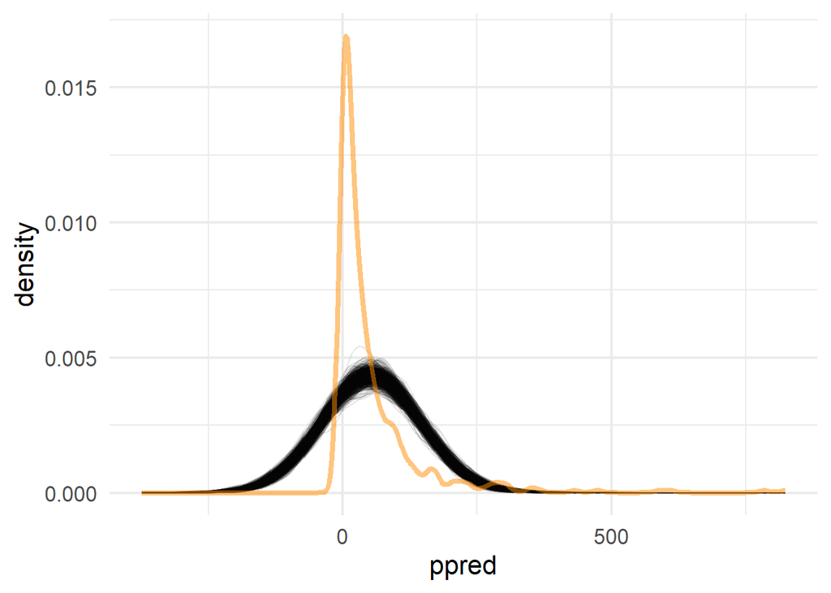

```r
# graph simulated datasets - one line for each mu,sigma combo
# this will take a while unless you reduce n above in extract.samples()!
gf_dens(~ppred, group = ~row_num,
        data = posterior_ppred,
        alpha = 0.1) |>
  # overlay actual data
  gf_dens(~household_annual_income,
          data = fiji,
          inherit = FALSE,
          color = 'darkorange',
          linewidth = 1.5)
```

> The posterior predictive distribution is a bit different than the actual data, maybe we need more variables, maybe it is correct.

## What’s next?

Think about how you might change or expand this model.

- How would the code look to fit a model with *more* predictors?
- Where might you want to use other distributions - which ones, and why?
- The model we tried hypothesized a *linear* association between `n_adults` and income. How could we model other situations (for example: nonlinear, variability that increases as the mean income increases, your other ideas?) These additions to the model are **much** easier in a Bayesian framework than a frequentist one!

## Practice

For your `water_expenses_pp`,

- Describe a model with one predictor
- Generate a prior predictive distribution
- Fit the model using `quap()`
- Sample from the posterior and graph the result
- Generate a posterior predictive distribution